# Ejemplo Real Clase 2: Feature Fusion + PCA en un Dataset Real

Autor/a

Sergio Nava

# 1 Objetivo del ejemplo

Construir un flujo completo y real:

1. Descargar un dataset publico de imagenes.
2. Extraer tres familias de descriptores: GLCM, Hu y color.
3. Fusionar caracteristicas en un unico vector por imagen.
4. Escalar, aplicar PCA y visualizar separabilidad.
5. Comparar contra descriptores individuales.

## 1.1 Mapeo rapido con Clase 2

El flujo implementa las mismas piezas vistas en clase:

- extraccion por bloques: `extract_glcm_features`, `extract_hu_features`, `extract_color_moments`;
- fusion de caracteristicas: `extract_fused_features`;
- construccion de matrices para analisis y modelo base.

La diferencia es de contexto: en este ejemplo se ejecuta extremo a extremo con dataset real para mostrar resultados reproducibles.

# 2 0. Librerias

```python
from pathlib import Path
import urllib.request
import tarfile
import random

import cv2
import numpy as np
import pandas as pd
import matplotlib.pyplot as plt

from scipy.stats import skew
from skimage.feature import graycomatrix, graycoprops
from sklearn.model_selection import train_test_split
from sklearn.pipeline import Pipeline
from sklearn.preprocessing import StandardScaler
from sklearn.decomposition import PCA
from sklearn.linear_model import LogisticRegression
from sklearn.metrics import accuracy_score
```

# 3 1. Descargar dataset real (Flowers)

```python
DATA_DIR = Path("datos_ejemplo")
FLOWERS_DIR = DATA_DIR / "flower_photos"
FLOWERS_URL = "https://storage.googleapis.com/download.tensorflow.org/example_images/flower_photos.tgz"


def ensure_flowers_dataset(url=FLOWERS_URL, out_dir=DATA_DIR):
    out_dir.mkdir(parents=True, exist_ok=True)
    archive_path = out_dir / "flower_photos.tgz"

    if not FLOWERS_DIR.exists():
        if not archive_path.exists():
            urllib.request.urlretrieve(url, archive_path)
        with tarfile.open(archive_path, "r:gz") as tar:
            tar.extractall(path=out_dir)


ensure_flowers_dataset()
```

```python
def load_flower_paths(classes=("daisy", "sunflowers", "roses"), max_per_class=160, seed=7):
    rng = random.Random(seed)
    paths = []
    labels = []

    for cls in classes:
        cls_dir = FLOWERS_DIR / cls
        imgs = [p for p in sorted(cls_dir.glob("*")) if p.suffix.lower() in {".jpg", ".jpeg", ".png"}]
        rng.shuffle(imgs)
        imgs = imgs[:max_per_class]

        paths.extend(imgs)
        labels.extend([cls] * len(imgs))

    return paths, np.array(labels)


paths_img, y = load_flower_paths()
pd.Series(y).value_counts()
```

```
daisy         160
sunflowers    160
roses         160
Name: count, dtype: int64
```

## 3.1 Vista rapida de imagenes por clase

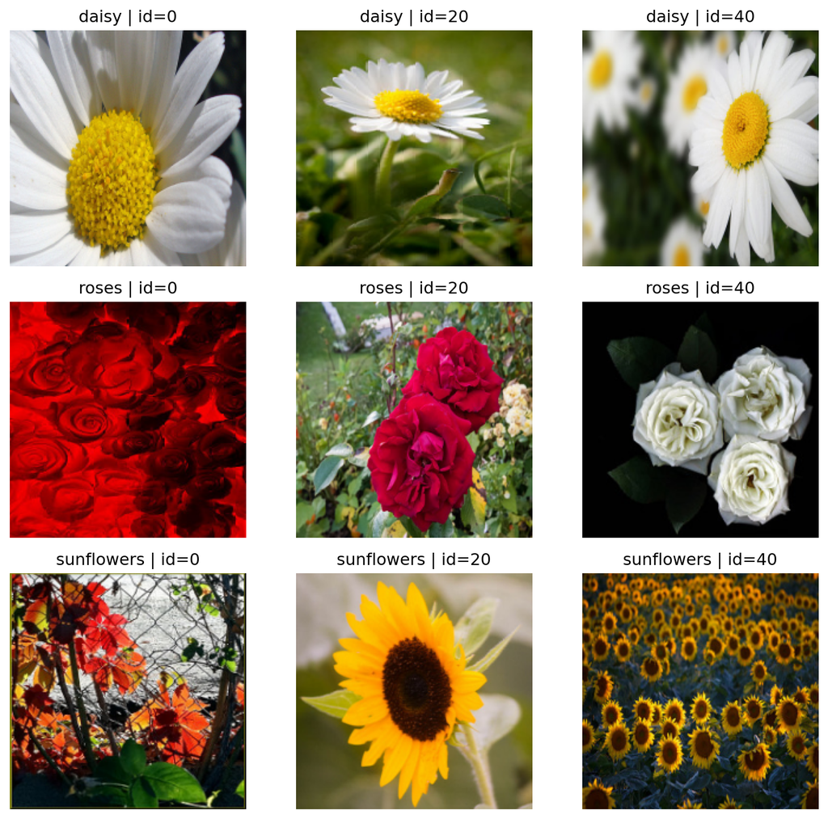

```python
# IDs fijos por clase (posiciones dentro de la lista ordenada de archivos)
FLOWER_SAMPLE_POS = {
    "daisy": [0, 20, 40],
    "roses": [0, 20, 40],
    "sunflowers": [0, 20, 40],
}


def show_flower_samples(paths, labels, sample_pos=FLOWER_SAMPLE_POS):
    classes = sorted(np.unique(labels))
    per_class = max(len(v) for v in sample_pos.values())
    fig, axes = plt.subplots(len(classes), per_class, figsize=(3.0 * per_class, 2.8 * len(classes)))

    if len(classes) == 1:
        axes = np.array([axes])

    for i, cls in enumerate(classes):
        cls_paths = sorted([p for p, yv in zip(paths, labels) if yv == cls], key=lambda p: p.name)
        picks = []
        for pos in sample_pos.get(cls, []):
            if 0 <= pos < len(cls_paths):
                picks.append(cls_paths[pos])

        for j in range(per_class):
            ax = axes[i, j]
            if j < len(picks):
                img_bgr = cv2.imread(str(picks[j]))
                img = cv2.cvtColor(img_bgr, cv2.COLOR_BGR2RGB)
                img = cv2.resize(img, (200, 200), interpolation=cv2.INTER_AREA)
                ax.imshow(img)
                ax.set_title(f"{cls} | id={sample_pos.get(cls, [])[j]}")
            ax.axis("off")

    plt.tight_layout()
    plt.show()


show_flower_samples(paths_img, y)
```

# 4 2. Extractores

```python
def read_rgb(path, size=(160, 160)):
    img_bgr = cv2.imread(str(path))
    if img_bgr is None:
        raise ValueError(f"No se pudo leer: {path}")
    img_rgb = cv2.cvtColor(img_bgr, cv2.COLOR_BGR2RGB)
    if size is not None:
        img_rgb = cv2.resize(img_rgb, size, interpolation=cv2.INTER_AREA)
    return img_rgb


def extract_glcm_features(
    image_gray,
    levels=32,
    distances=(1, 3, 5),
    angles=(0, np.pi / 4, np.pi / 2, 3 * np.pi / 4),
):
    q = (image_gray / 256 * levels).astype(np.uint8)
    q = np.clip(q, 0, levels - 1)

    glcm = graycomatrix(
        q,
        distances=list(distances),
        angles=list(angles),
        levels=levels,
        symmetric=True,
        normed=True,
    )

    props = ["contrast", "dissimilarity", "homogeneity", "ASM", "energy", "correlation"]
    feats = []
    names = []
    for prop in props:
        vals = graycoprops(glcm, prop)
        for i, d in enumerate(distances):
            for j, _ in enumerate(angles):
                feats.append(vals[i, j])
                names.append(f"glcm_{prop}_d{d}_a{j}")

    return np.array(feats, dtype=float), names


def extract_hu_features(image_gray, threshold=110):
    _, mask = cv2.threshold(image_gray, threshold, 255, cv2.THRESH_BINARY)
    moments = cv2.moments(mask)
    hu = cv2.HuMoments(moments).flatten()
    hu_log = -np.sign(hu) * np.log10(np.abs(hu) + 1e-12)
    names = [f"hu_{i+1}" for i in range(7)]
    return hu_log.astype(float), names


def extract_color_moments(image_rgb):
    feats = []
    names = []
    for idx in range(3):
        channel = image_rgb[:, :, idx].astype(np.float64).ravel()
        feats.extend([
            channel.mean(),
            channel.std(ddof=0),
            skew(channel, bias=False),
        ])
        cname = ["R", "G", "B"][idx]
        names.extend([
            f"color_mean_{cname}",
            f"color_std_{cname}",
            f"color_skew_{cname}",
        ])
    return np.array(feats, dtype=float), names


def extract_fused_features(image_rgb):
    gray = cv2.cvtColor(image_rgb, cv2.COLOR_RGB2GRAY)
    g, g_names = extract_glcm_features(gray)
    h, h_names = extract_hu_features(gray)
    c, c_names = extract_color_moments(image_rgb)
    return np.concatenate([g, h, c]), g_names + h_names + c_names
```

# 5 3. Matrices de caracteristicas

```python
def build_matrix(paths, extractor, input_type="rgb"):
    rows = []
    for p in paths:
        img = read_rgb(p)
        src = cv2.cvtColor(img, cv2.COLOR_RGB2GRAY) if input_type == "gray" else img
        vec, _ = extractor(src)
        rows.append(vec)
    return np.vstack(rows)


X_glcm = build_matrix(paths_img, extract_glcm_features, input_type="gray")
X_hu = build_matrix(paths_img, extract_hu_features, input_type="gray")
X_color = build_matrix(paths_img, extract_color_moments, input_type="rgb")
X_fused = build_matrix(paths_img, extract_fused_features, input_type="rgb")

X_glcm.shape, X_hu.shape, X_color.shape, X_fused.shape
```

```
((480, 72), (480, 7), (480, 9), (480, 88))
```

# 6 4. Comparacion de rendimiento base

```python
def evaluate_accuracy(X, y, test_size=0.25, random_state=42):
    X_train, X_test, y_train, y_test = train_test_split(
        X, y, test_size=test_size, stratify=y, random_state=random_state
    )

    pipe = Pipeline([
        ("scaler", StandardScaler()),
        ("clf", LogisticRegression(max_iter=3000)),
    ])
    pipe.fit(X_train, y_train)
    pred = pipe.predict(X_test)
    return accuracy_score(y_test, pred)


acc_glcm = evaluate_accuracy(X_glcm, y)
acc_hu = evaluate_accuracy(X_hu, y)
acc_color = evaluate_accuracy(X_color, y)
acc_fused = evaluate_accuracy(X_fused, y)

pd.DataFrame(
    {
        "descriptor": ["GLCM", "Hu", "Color", "Fusion (GLCM+Hu+Color)"],
        "accuracy": [acc_glcm, acc_hu, acc_color, acc_fused],
    }
)
```

|  | descriptor | accuracy |
| --- | --- | --- |
| 0 | GLCM | 0.566667 |
| 1 | Hu | 0.450000 |
| 2 | Color | 0.641667 |
| 3 | Fusion (GLCM+Hu+Color) | 0.700000 |

# 7 5. PCA sobre espacio fusionado

```python
scaler = StandardScaler()
X_fused_scaled = scaler.fit_transform(X_fused)

pca2 = PCA(n_components=2, random_state=42)
Z2 = pca2.fit_transform(X_fused_scaled)

pca3 = PCA(n_components=3, random_state=42)
Z3 = pca3.fit_transform(X_fused_scaled)

pca2.explained_variance_ratio_, pca3.explained_variance_ratio_
```

```
(array([0.48496506, 0.20750486]), array([0.48496506, 0.20750486, 0.1013862 ]))
```

## 7.1 Visualizacion 2D

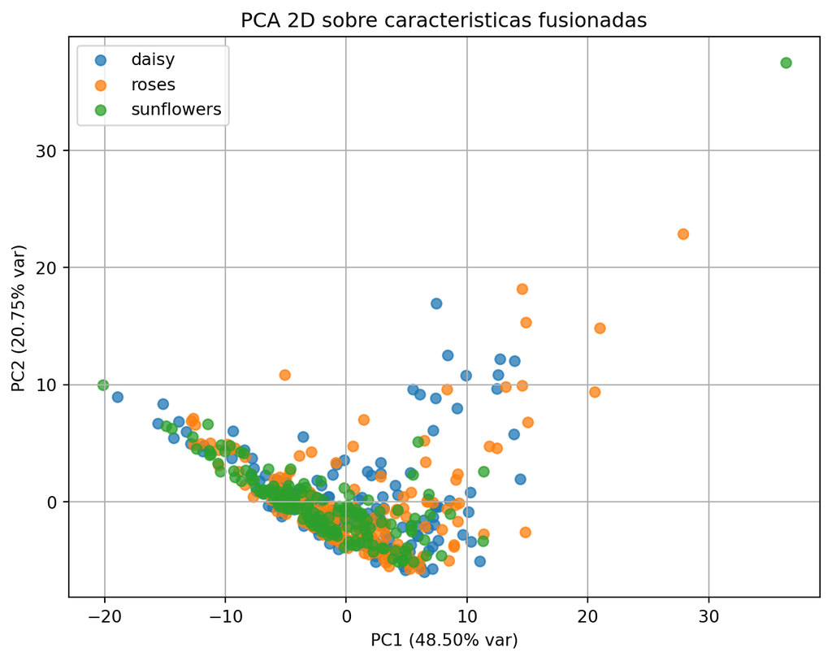

```python
plt.figure(figsize=(8, 6))
for cls in np.unique(y):
    idx = y == cls
    plt.scatter(Z2[idx, 0], Z2[idx, 1], label=cls, alpha=0.75)

plt.xlabel(f"PC1 ({pca2.explained_variance_ratio_[0] * 100:.2f}% var)")
plt.ylabel(f"PC2 ({pca2.explained_variance_ratio_[1] * 100:.2f}% var)")
plt.title("PCA 2D sobre caracteristicas fusionadas")
plt.legend()
plt.grid(True)
plt.show()
```

## 7.2 Visualizacion 3D

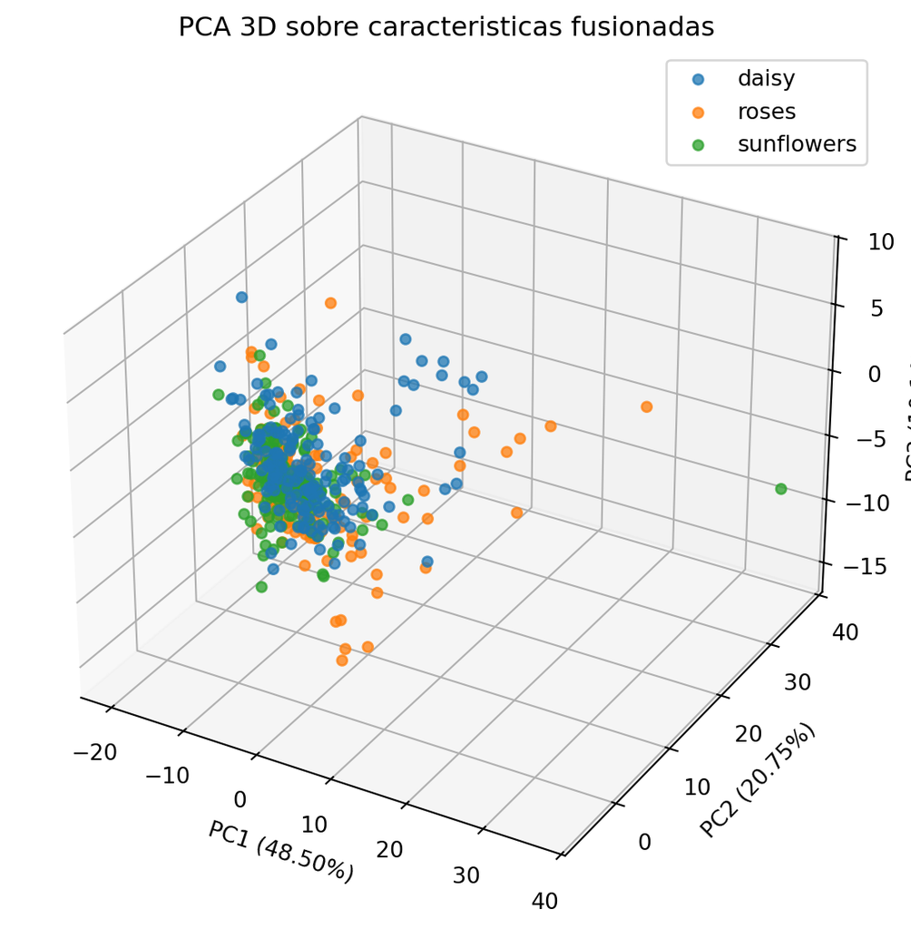

```python
fig = plt.figure(figsize=(9, 7))
ax = fig.add_subplot(111, projection="3d")

for cls in np.unique(y):
    idx = y == cls
    ax.scatter(Z3[idx, 0], Z3[idx, 1], Z3[idx, 2], label=cls, alpha=0.75)

ax.set_xlabel(f"PC1 ({pca3.explained_variance_ratio_[0] * 100:.2f}%)")
ax.set_ylabel(f"PC2 ({pca3.explained_variance_ratio_[1] * 100:.2f}%)")
ax.set_zlabel(f"PC3 ({pca3.explained_variance_ratio_[2] * 100:.2f}%)")
ax.set_title("PCA 3D sobre caracteristicas fusionadas")
ax.legend()
plt.show()
```

# 8 6. Lectura didactica para presentar

- Si **Fusion** supera a bloques individuales, hay evidencia de complementariedad entre textura, forma y color.
- Si PCA muestra grupos relativamente separados, hay estructura discriminativa en el espacio fusionado.
- Si hay solapamiento fuerte, puedes discutir mejoras:
  - mayor limpieza de segmentacion para Hu,
  - parametros de GLCM por region,
  - otros espacios de color (HSV o Lab),
  - clasificadores no lineales.

# 9 7. Cierre

Este ejemplo aterriza la narrativa de la Clase 2 con un flujo real completo:

1. dataset publico,
2. extraccion por bloques,
3. fusion,
4. PCA,
5. comparacion cuantitativa.